# Spaceship_Titanic

Este código fue desarrollado como parte de la competencia Spaceship Titanic en Kaggle, donde el objetivo es predecir si los pasajeros fueron transportados a través de un viaje intergaláctico. Para abordar este desafío, se implementaron y evaluaron seis modelos diferentes de machine learning, cada uno con su propio enfoque y características.

Los modelos utilizados en este análisis incluyen:

- Regresión Logística Multinomial: Un modelo estadístico que se utiliza para predecir la probabilidad de que un pasajero pertenezca a una de las categorías de transporte, basándose en las características de los datos.
- Análisis Discriminante Lineal (LDA): Un método que busca encontrar una combinación lineal de características que separen mejor las clases de los pasajeros transportados y no transportados.
- Árbol de Decisión: Un modelo que utiliza una estructura de árbol para tomar decisiones basadas en las características de los pasajeros, permitiendo una interpretación clara de las decisiones del modelo.
- Bagging: Un enfoque de ensemble que combina múltiples modelos de árboles de decisión para mejorar la estabilidad y precisión de las predicciones.
- Random Forest: Una extensión del bagging que utiliza un conjunto de árboles de decisión, cada uno entrenado con un subconjunto aleatorio de los datos, para mejorar la precisión y reducir el riesgo de sobreajuste.
- Boosting con Gradient Boosting: Un método que combina múltiples modelos débiles (generalmente árboles de decisión) para crear un modelo fuerte, ajustando iterativamente los errores de los modelos anteriores.

Después de entrenar y evaluar estos modelos, se compararon sus rendimientos para determinar cuál de ellos ofrecía la mejor precisión y capacidad de generalización en el conjunto de datos de prueba. -

En esta sección se importan todas las librerías a utilizar en el código.

```python
# Importar librerías necesarias
import numpy as np
import pandas as pd
import matplotlib.pyplot as plt

# Preprocesamiento
from sklearn.impute import SimpleImputer
from sklearn.preprocessing import StandardScaler
from sklearn.pipeline import make_pipeline

# Modelos
from sklearn.linear_model import LogisticRegression
from sklearn.discriminant_analysis import LinearDiscriminantAnalysis as LDA
from sklearn.tree import DecisionTreeClassifier as DTC
from sklearn.ensemble import RandomForestClassifier
from sklearn.ensemble import GradientBoostingClassifier as GBC
from sklearn.ensemble import BaggingClassifier

# Evaluación y validación
from sklearn.model_selection import train_test_split, cross_val_score, StratifiedKFold
from sklearn.metrics import accuracy_score, f1_score, confusion_matrix, classification_report

# Visualización
from sklearn.tree import plot_tree
```

Todo este cuadro de código es la limpieza de datos y el trabajo del dataset.

```python
import pandas as pd
from sklearn.impute import SimpleImputer

# Cargar los datos desde archivos CSV
df_entrenamiento = pd.read_csv('train.csv')
df_prueba_no_mod = pd.read_csv('test.csv')
df_prueba = pd.read_csv('test.csv')

# Exploración inicial
print("Información del conjunto de entrenamiento:")
print(df_entrenamiento.info())
print("\nPrimeras filas del conjunto de entrenamiento:")
print(df_entrenamiento.head())

print("\nInformación del conjunto de prueba:")
print(df_prueba.info())
print("\nPrimeras filas del conjunto de prueba:")
print(df_prueba.head())

# Verificar valores faltantes
print("\nNúmero de valores faltantes en el conjunto de entrenamiento:")
print(df_entrenamiento.isnull().sum().sort_values(ascending=False))

# Preprocesamiento
columnas_eliminar = ['PassengerId', 'Name', 'Cabin']
for df in [df_entrenamiento, df_prueba]:
    df.drop(columnas_eliminar[:-1], axis=1, inplace=True)  # Eliminar 'PassengerId' y 'Name'
    df['Deck'] = df['Cabin'].str[0]  # Extraer la letra de la columna 'Cabin'
    df.drop('Cabin', axis=1, inplace=True)  # Eliminar la columna 'Cabin'

# Función para codificar variables categóricas en variables dummy
def encode_categorical_features(df):
    cat_columns = ['HomePlanet', 'CryoSleep', 'Deck', 'Destination', 'VIP']
    df = pd.get_dummies(df, columns=cat_columns, drop_first=True, prefix=cat_columns)
    return df

# Aplicar la codificación a los conjuntos de datos
df_entrenamiento_mod = encode_categorical_features(df_entrenamiento)
df_prueba_mod = encode_categorical_features(df_prueba)

# Imputación de valores faltantes con la estrategia "más frecuente"
imputador = SimpleImputer(strategy='most_frequent')

# Aplicar el imputador a los datos de entrenamiento
X_entrenamiento_imputado = pd.DataFrame(imputador.fit_transform(df_entrenamiento_mod.drop('Transported', axis=1)),
                                        columns=df_entrenamiento_mod.drop('Transported', axis=1).columns)

# Aplicar el imputador a los datos de prueba
X_prueba_imputado = pd.DataFrame(imputador.transform(df_prueba_mod),
                                 columns=df_prueba_mod.columns)

# Convertir variables booleanas a valores numéricos (0 y 1)
X_entrenamiento_imputado = X_entrenamiento_imputado.astype(int)
X_prueba_imputado = X_prueba_imputado.astype(int)

# Visualización de la estructura final de los datos
print("\nEstructura final del conjunto de entrenamiento:")
print(X_entrenamiento_imputado.info())
print("\nPrimeras filas del conjunto de entrenamiento final:")
print(X_entrenamiento_imputado.head())

print("\nEstructura final del conjunto de prueba:")
print(X_prueba_imputado.info())
print("\nPrimeras filas del conjunto de prueba final:")
print(X_prueba_imputado.head())

# Verificar valores nulos después de la imputación
print("\nNúmero de valores nulos en el conjunto de entrenamiento después de la imputación:")
print(X_entrenamiento_imputado.isnull().sum().sort_values(ascending=False))
```

```
Información del conjunto de entrenamiento:
<class 'pandas.core.frame.DataFrame'>
RangeIndex: 8693 entries, 0 to 8692
Data columns (total 14 columns):
 #   Column        Non-Null Count  Dtype
---  ------        --------------  -----
 0   PassengerId   8693 non-null   object
 1   HomePlanet    8492 non-null   object
 2   CryoSleep     8476 non-null   object
 3   Cabin         8494 non-null   object
 4   Destination   8511 non-null   object
 5   Age           8514 non-null   float64
 6   VIP           8490 non-null   object
 7   RoomService   8512 non-null   float64
 8   FoodCourt     8510 non-null   float64
 9   ShoppingMall  8485 non-null   float64
 10  Spa           8510 non-null   float64
 11  VRDeck        8505 non-null   float64
 12  Name          8493 non-null   object
 13  Transported   8693 non-null   bool
dtypes: bool(1), float64(6), object(7)
memory usage: 891.5+ KB
None

Primeras filas del conjunto de entrenamiento:
  PassengerId HomePlanet CryoSleep  Cabin  Destination   Age    VIP  \
0     0001_01     Europa     False  B/0/P  TRAPPIST-1e  39.0  False
1     0002_01      Earth     False  F/0/S  TRAPPIST-1e  24.0  False
2     0003_01     Europa     False  A/0/S  TRAPPIST-1e  58.0   True
3     0003_02     Europa     False  A/0/S  TRAPPIST-1e  33.0  False
4     0004_01      Earth     False  F/1/S  TRAPPIST-1e  16.0  False

   RoomService  FoodCourt  ShoppingMall     Spa  VRDeck               Name  \
0          0.0        0.0           0.0     0.0     0.0    Maham Ofracculy
1        109.0        9.0          25.0   549.0    44.0       Juanna Vines
2         43.0     3576.0           0.0  6715.0    49.0      Altark Susent
3          0.0     1283.0         371.0  3329.0   193.0       Solam Susent
4        303.0       70.0         151.0   565.0     2.0  Willy Santantines

   Transported
```

[output cut: 183 more lines]

```
VRDeck                       0
HomePlanet_Europa            0
HomePlanet_Mars              0
CryoSleep_True               0
Deck_B                       0
Deck_C                       0
Deck_D                       0
Deck_E                       0
Deck_F                       0
Deck_G                       0
Deck_T                       0
Destination_PSO J318.5-22    0
Destination_TRAPPIST-1e      0
VIP_True                     0
dtype: int64
```

Gráficas (solo por curiosidad) para comparar la distribución de 1 variable (edad) en entrenamiento y prueba.

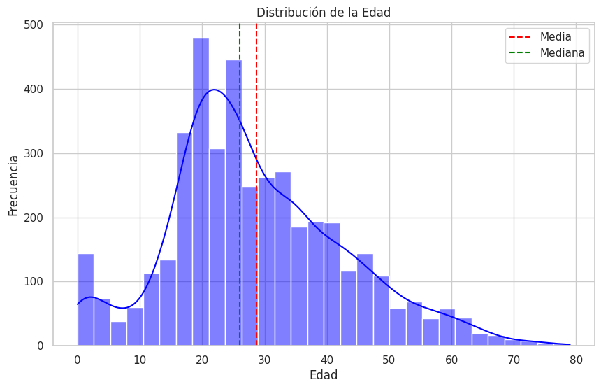

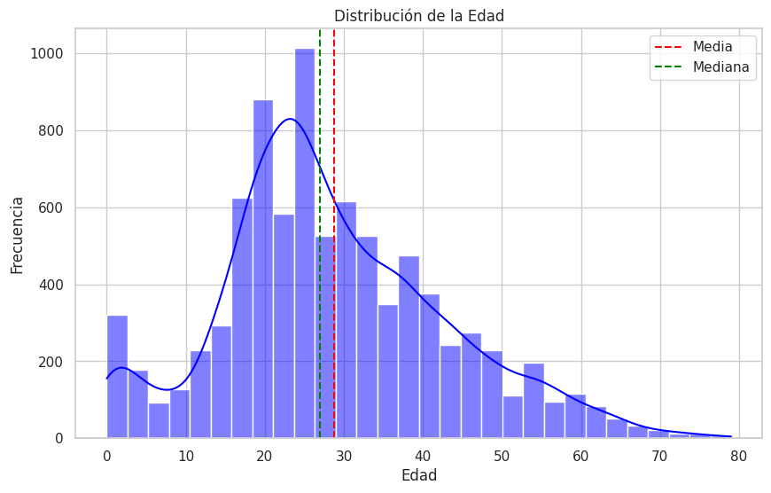

```python
sns.set(style="whitegrid")

# Histograma de la distribución de la Edad en datos de prueba
plt.figure(figsize=(10, 6))
sns.histplot(df_prueba_no_mod['Age'], bins=30, kde=True, color='blue')
plt.title('Distribución de la Edad')
plt.xlabel('Edad')
plt.ylabel('Frecuencia')
plt.axvline(df_prueba_no_mod['Age'].mean(), color='red', linestyle='--', label='Media')
plt.axvline(df_prueba_no_mod['Age'].median(), color='green', linestyle='--', label='Mediana')
plt.legend()
plt.show()

# Histograma de la distribución de la Edad en datos de entrenamiento modificados
plt.figure(figsize=(10, 6))
sns.histplot(X_entrenamiento_imputado['Age'], bins=30, kde=True, color='blue')
plt.title('Distribución de la Edad')
plt.xlabel('Edad')
plt.ylabel('Frecuencia')
plt.axvline(X_entrenamiento_imputado['Age'].mean(), color='red', linestyle='--', label='Media')
plt.axvline(X_entrenamiento_imputado['Age'].median(), color='green', linestyle='--', label='Mediana')
plt.legend()
plt.show()
```

Modelo de Regresión Logística Multinomial.

```python
# Definir las variables independientes (X) y dependientes (Y)
X = X_entrenamiento_imputado  # Conjunto de características imputadas
Y = df_entrenamiento_mod['Transported']  # Variable objetivo

# Dividir los datos en conjuntos de entrenamiento y prueba
X_train, X_test, Y_train, Y_test = train_test_split(X, Y, train_size=0.8, random_state=42)

# Crear el modelo de regresión logística
modelo_regresion_logistica = LogisticRegression(penalty=None, class_weight="balanced", max_iter=1000)

# Realizar validación cruzada con 10 particiones
puntajes_cv = cross_val_score(modelo_regresion_logistica, X_train, Y_train, cv=10, scoring='accuracy')

# Imprimir los puntajes de validación cruzada
print("\n" + "="*50)
print("Puntajes de validación cruzada (10 particiones):")
print(puntajes_cv)
print("="*50)

# Imprimir la accuracy promedio de la validación cruzada
print(f"\nAccuracy promedio de validación cruzada: {puntajes_cv.mean():.4f}")
print("="*50)

# Ajustar el modelo a los datos de entrenamiento
modelo_regresion_logistica.fit(X_train, Y_train)

# Realizar predicciones en el conjunto de prueba
predicciones = modelo_regresion_logistica.predict(X_test)

# Calcular la exactitud del modelo en el conjunto de prueba
accuracy = np.mean(predicciones == Y_test)

# Imprimir la exactitud del modelo en el conjunto de prueba
print(f"\nAccuracy del modelo en el conjunto de prueba: {accuracy:.4f}")
print("="*50)
```

[output not shown]

[output cut: 25 more lines]

[output not shown]

```
==================================================
Puntajes de validación cruzada (10 particiones):
[0.7887931  0.78017241 0.78591954 0.79166667 0.79280576 0.78705036
 0.80431655 0.77553957 0.80143885 0.79856115]
==================================================

Accuracy promedio de validación cruzada: 0.7906
==================================================

Accuracy del modelo en el conjunto de prueba: 0.7867
==================================================
```

Modelo de Linear Discriminant Analysis (LDA)

```python
# Estandarizar las características, que es uno de los supuestos de LDA
scaler = StandardScaler()

# Crear un pipeline que primero estandariza los datos y luego ajusta el modelo LDA
modelo_lda = make_pipeline(scaler, LDA())

# Ajustar el modelo a los datos de entrenamiento
modelo_lda.fit(X_train, Y_train)

# Realizar predicciones en el conjunto de prueba
predicciones_lda = modelo_lda.predict(X_test)

# Calcular las probabilidades de las predicciones
probabilidades_lda = modelo_lda.predict_proba(X_test)

# Generar y mostrar la matriz de confusión
matriz_confusion = confusion_matrix(Y_test, predicciones_lda)
print("\n" + "="*50)
print("Matriz de Confusión:")
print(matriz_confusion)
print("="*50)

# Generar y mostrar el reporte de clasificación
reporte_clasificacion = classification_report(Y_test, predicciones_lda)
print("Reporte de Clasificación:")
print(reporte_clasificacion)

# Calcular y mostrar la exactitud del modelo en el conjunto de prueba
accuracy_test = accuracy_score(Y_test, predicciones_lda)
print(f"Accuracy en el conjunto de prueba: {accuracy_test:.4f}")
print("="*50)

# Realizar validación cruzada con 10 particiones
puntajes_cv = cross_val_score(modelo_lda, X_train, Y_train, cv=10, scoring='accuracy')

# Imprimir los puntajes de validación cruzada
print(f"Puntajes de validación cruzada: {puntajes_cv}")
print(f"Accuracy promedio de validación cruzada: {puntajes_cv.mean():.4f}")
print("="*50)
```

```
==================================================
Matriz de Confusión:
[[699 162]
 [255 623]]
==================================================
Reporte de Clasificación:
              precision    recall  f1-score   support

       False       0.73      0.81      0.77       861
        True       0.79      0.71      0.75       878

    accuracy                           0.76      1739
   macro avg       0.76      0.76      0.76      1739
weighted avg       0.76      0.76      0.76      1739

Accuracy en el conjunto de prueba: 0.7602
==================================================
Puntajes de validación cruzada: [0.74137931 0.76293103 0.75862069 0.79022989 0.76834532 0.75971223
 0.77841727 0.74676259 0.77841727 0.78417266]
Accuracy promedio de validación cruzada: 0.7669
==================================================
```

Modelo de Árbol de Decisión (sin poda y podado).

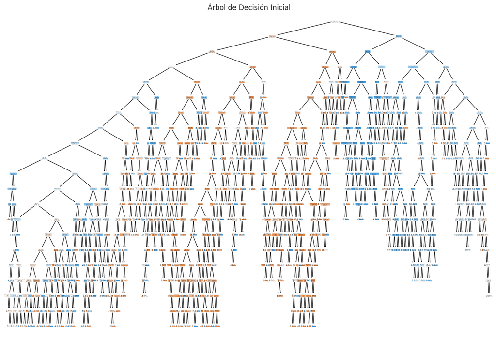

```
==================================================
Accuracy inicial: 0.7389304197814837
F1-score inicial: 0.7488938053097345
==================================================
Mejor Alpha: 0.001
```

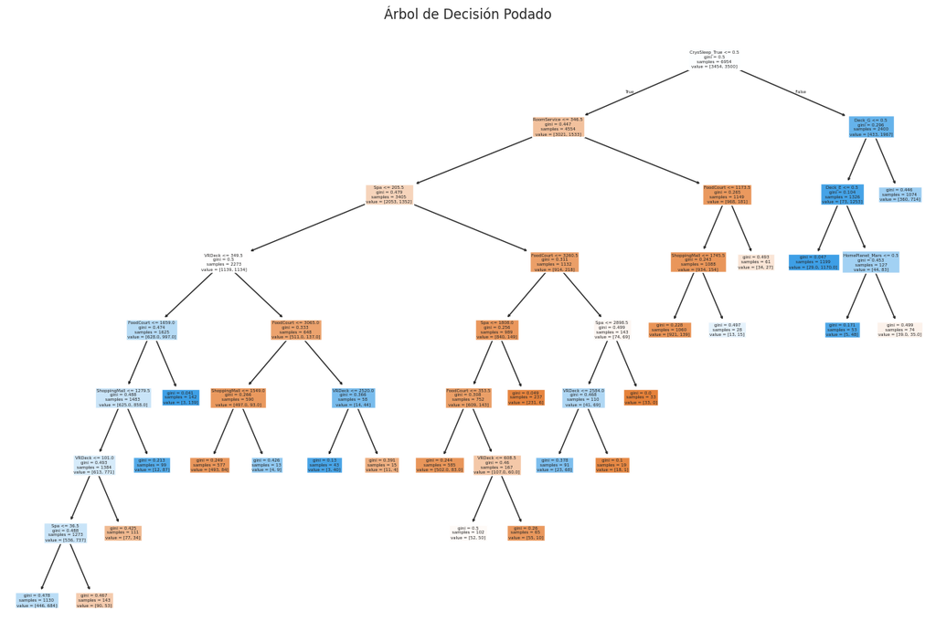

```
==================================================
Accuracy del árbol podado: 0.7791834387579069
F1-score del árbol podado: 0.7944325481798715
==================================================
```

```python
# Crear y ajustar el modelo de árbol de decisión inicial
arbol_decision = DTC(random_state=0, max_depth=20, min_samples_split=10)
arbol_decision.fit(X_train, Y_train)

# Visualizar el árbol de decisión inicial
plt.figure(figsize=(15, 10))
plot_tree(arbol_decision, filled=True, feature_names=X_train.columns)
plt.title("Árbol de Decisión Inicial")
plt.show()

# Realizar predicciones en el conjunto de prueba
predicciones_iniciales = arbol_decision.predict(X_test)

# Calcular y mostrar la exactitud y el F1-score del modelo inicial
accuracy_inicial = accuracy_score(Y_test, predicciones_iniciales)
f1_inicial = f1_score(Y_test, predicciones_iniciales)
print("="*50)
print("Accuracy inicial:", accuracy_inicial)
print("F1-score inicial:", f1_inicial)
print("="*50)

# Configurar la validación cruzada estratificada
skf = StratifiedKFold(n_splits=4)

# Definir un rango de valores para el parámetro de complejidad (ccp_alpha)
ccp = np.linspace(0.001, 0.2, 250)
cv_scores = []

# Evaluar el rendimiento del árbol de decisión podado para diferentes valores de ccp_alpha
for alpha in ccp:
    arbol_podado = DTC(ccp_alpha=alpha, random_state=0, max_depth=8, min_samples_split=10)
    cv_scores.append(np.mean(cross_val_score(arbol_podado, X_train, Y_train, cv=skf, scoring='f1')))

# Encontrar el mejor valor de alpha basado en el rendimiento promedio
mejor_alpha = ccp[np.argmax(cv_scores)]
print("Mejor Alpha:", mejor_alpha)

# Ajustar el árbol de decisión podado con el mejor valor de alpha
arbol_podado = DTC(ccp_alpha=mejor_alpha, random_state=0, max_depth=8, min_samples_split=10)
arbol_podado.fit(X_train, Y_train)

# Visualizar el árbol de decisión podado
plt.figure(figsize=(15, 10))
plot_tree(arbol_podado, filled=True, feature_names=X_train.columns)
plt.title("Árbol de Decisión Podado")
plt.show()

# Realizar predicciones en el conjunto de prueba con el árbol podado
predicciones_podadas = arbol_podado.predict(X_test)

# Calcular y mostrar la exactitud y el F1-score del árbol podado
accuracy_podado = accuracy_score(Y_test, predicciones_podadas)
f1_podado = f1_score(Y_test, predicciones_podadas)
print("="*50)
print("Accuracy del árbol podado:", accuracy_podado)
print("F1-score del árbol podado:", f1_podado)
print("="*50)
```

Modelo de Bagging.

```python
# Crear y ajustar el modelo de Bagging con un clasificador de árbol de decisión como estimador base
bagging_model = BaggingClassifier(estimator=DecisionTreeClassifier(), n_estimators=100, random_state=42)
bagging_model.fit(X_train, Y_train)

# Realizar predicciones en el conjunto de prueba
predicciones_bagging = bagging_model.predict(X_test)

# Calcular la exactitud y el F1-score del modelo en el conjunto de prueba
acc_bagging = accuracy_score(Y_test, predicciones_bagging)
f1_bagging = f1_score(Y_test, predicciones_bagging, average='weighted')

# Imprimir los resultados de la evaluación del modelo
print("="*50)
print(f"Accuracy del modelo de Bagging en el conjunto de prueba: {acc_bagging:.5f}")
print(f"F1-score del modelo de Bagging en el conjunto de prueba: {f1_bagging:.5f}")
print("="*50)

# Generar y mostrar la matriz de confusión
print("\nMatriz de confusión:\n", confusion_matrix(Y_test, predicciones_bagging))

# Generar y mostrar el reporte de clasificación
print("\nReporte de clasificación:\n", classification_report(Y_test, predicciones_bagging))

# Realizar validación cruzada con 10 particiones
puntajes_cv = cross_val_score(bagging_model, X_train, Y_train, cv=10, scoring='accuracy')

# Imprimir los puntajes de validación cruzada
print(f"Puntajes de validación cruzada: {puntajes_cv}")
print(f"Accuracy promedio de validación cruzada: {puntajes_cv.mean():.4f}")
print("="*50)
```

```
==================================================
Accuracy del modelo de Bagging en el conjunto de prueba: 0.77401
F1-score del modelo de Bagging en el conjunto de prueba: 0.77401
==================================================

Matriz de confusión:
 [[667 194]
 [199 679]]

Reporte de clasificación:
               precision    recall  f1-score   support

       False       0.77      0.77      0.77       861
        True       0.78      0.77      0.78       878

    accuracy                           0.77      1739
   macro avg       0.77      0.77      0.77      1739
weighted avg       0.77      0.77      0.77      1739

Puntajes de validación cruzada: [0.78448276 0.77155172 0.79597701 0.80172414 0.78417266 0.77553957
 0.78992806 0.78129496 0.78705036 0.80143885]
Accuracy promedio de validación cruzada: 0.7873
==================================================
```

Modelo de Random Forest.

```python
# Crear y ajustar el modelo de Random Forest
rf_model = RandomForestClassifier(n_estimators=100, random_state=42)
rf_model.fit(X_train, Y_train)

# Realizar predicciones en el conjunto de prueba
RFpredict = rf_model.predict(X_test)

# Calcular la exactitud y el F1-score del modelo en el conjunto de prueba
acc_rf = accuracy_score(Y_test, RFpredict)
f1_rf = f1_score(Y_test, RFpredict)

# Imprimir los resultados de la evaluación del modelo
print("="*50)
print("Accuracy del modelo Random Forest en el conjunto de prueba:", acc_rf)
print("F1-score del modelo Random Forest en el conjunto de prueba:", f1_rf)
print("="*50)

# Generar y mostrar la matriz de confusión
cm_rf = confusion_matrix(Y_test, RFpredict)
print("Matriz de confusión:\n", cm_rf)

# Generar y mostrar el reporte de clasificación
rep_rf = classification_report(Y_test, RFpredict)
print("\nReporte de clasificación:\n", rep_rf)

# Realizar validación cruzada con 10 particiones
puntajes_cv = cross_val_score(rf_model, X_train, Y_train, cv=10, scoring='accuracy')

# Imprimir los puntajes de validación cruzada
print(f"Puntajes de validación cruzada: {puntajes_cv}")
print(f"Accuracy promedio de validación cruzada: {puntajes_cv.mean():.4f}")
print("="*50)
```

```
==================================================
Accuracy del modelo Random Forest en el conjunto de prueba: 0.78205865439908
F1-score del modelo Random Forest en el conjunto de prueba: 0.7835522558537978
==================================================
Matriz de confusión:
 [[674 187]
 [192 686]]

Reporte de clasificación:
               precision    recall  f1-score   support

       False       0.78      0.78      0.78       861
        True       0.79      0.78      0.78       878

    accuracy                           0.78      1739
   macro avg       0.78      0.78      0.78      1739
weighted avg       0.78      0.78      0.78      1739

Puntajes de validación cruzada: [0.77873563 0.77729885 0.77873563 0.79454023 0.79280576 0.79136691
 0.79136691 0.77697842 0.78992806 0.79856115]
Accuracy promedio de validación cruzada: 0.7870
==================================================
```

Modelo de Boosting utilizando Gradient Boosting.

```python
# Crear y ajustar el modelo de Gradient Boosting
gbc = GBC(n_estimators=100, random_state=42)
gbc.fit(X_train, Y_train)

# Realizar predicciones en el conjunto de prueba
predGBC = gbc.predict(X_test)

# Calcular la exactitud promedio de validación cruzada
accBoost_GBC = cross_val_score(gbc, X_train, Y_train, cv=5, scoring="accuracy")
print("="*50)
print(f'Accuracy promedio de validación cruzada Gradient Boosting: {accBoost_GBC.mean():.5f}')

# Calcular la exactitud y el F1-score del modelo en el conjunto de prueba
acc_GBC = accuracy_score(Y_test, predGBC)
f1_GBC = f1_score(Y_test, predGBC, average='weighted')

# Imprimir los resultados de la evaluación del modelo
print(f"Accuracy de Gradient Boosting en el conjunto de prueba: {acc_GBC:.5f}")
print(f"F1-score de Gradient Boosting en el conjunto de prueba: {f1_GBC:.5f}")
print("="*50)

# Generar y mostrar la matriz de confusión
print("\nMatriz de confusión Gradient Boosting:\n", confusion_matrix(Y_test, predGBC))

# Generar y mostrar el reporte de clasificación
print("\nReporte de clasificación Gradient Boosting:\n", classification_report(Y_test, predGBC))
print("="*50)
```

```
==================================================
Accuracy promedio de validación cruzada Gradient Boosting: 0.79897
Accuracy de Gradient Boosting en el conjunto de prueba: 0.78953
F1-score de Gradient Boosting en el conjunto de prueba: 0.78856
==================================================

Matriz de confusión Gradient Boosting:
 [[623 238]
 [128 750]]

Reporte de clasificación Gradient Boosting:
               precision    recall  f1-score   support

       False       0.83      0.72      0.77       861
        True       0.76      0.85      0.80       878

    accuracy                           0.79      1739
   macro avg       0.79      0.79      0.79      1739
weighted avg       0.79      0.79      0.79      1739

==================================================
```

Análisis Comparativo.

Mejor Modelo: **Gradient Boosting**

- El modelo de Gradient Boosting se destaca como el mejor en términos de desempeño, con una accuracy promedio en validación cruzada de 0.79897 y un accuracy en el conjunto de prueba de 0.7895. Estos resultados sugieren que el modelo no solo se ajusta bien a los datos de entrenamiento, sino que también generaliza de manera efectiva a datos no vistos.

Regresión Logística Multinomial

- Este modelo muestra un rendimiento competitivo, con una accuracy promedio en validación cruzada de 0.7906 y un accuracy en el conjunto de prueba de 0.7867. A pesar de su simplicidad, su desempeño es cercano al de Gradient Boosting, aunque ligeramente inferior.

Random Forest y Bagging

- Tienen un rendimiento similar, con accuracy en el conjunto de prueba de 0.7821 y 0.7740, respectivamente. Sin embargo, su accuracy promedio de validación cruzada es comparable, lo que indica que ambos modelos son robustos, pero no alcanzan el rendimiento de los modelos anteriores.

Resultado y Submission.

```python
# Realizar predicciones en el conjunto de prueba utilizando el modelo de Gradient Boosting
predicciones_finales = gbc.predict(X_prueba_imputado)

# Convertir las predicciones a valores booleanos (True/False) basados en un umbral de 0.5
predicciones_bool = (predicciones_finales > 0.5).astype(bool)

# Asignar las predicciones booleanas a la columna 'Transported' del DataFrame original de prueba
# df_prueba_no_mod es el DataFrame que contiene los datos originales de prueba sin modificar
df_prueba_no_mod['Transported'] = predicciones_bool

# Crear un nuevo DataFrame que solo contenga las columnas 'PassengerId' y 'Transported'
# Esto es para el envío de la Competencia de KAGGLE
df_final = df_prueba_no_mod[['PassengerId', 'Transported']]

# Imprimir las primeras 10 filas del DataFrame final que contiene los resultados
print(df_final.head(10))
```

```
  PassengerId  Transported
0     0013_01         True
1     0018_01        False
2     0019_01         True
3     0021_01         True
4     0023_01         True
5     0027_01         True
6     0029_01         True
7     0032_01         True
8     0032_02         True
9     0033_01         True
```

```python
# Guardar el DataFrame final en un archivo CSV para el envío a Kaggle
df_final.to_csv('Spaceship_T_sub.csv', index=False)

# Para descargar el archivo en un entorno como Jupyter Notebook o Google Colab
from google.colab import files

# Descarga del archivo
files.download('Spaceship_T_sub.csv')
```

Se usó chatgpt para los comentarios y hacer el código más bonito.